# var_setting_2

dawon

2025-04-27

#import packages

# children present at journey category

###Filter out only adult respondants

#caregiver’s age distribution

```python
# Group by age and count unique journeys
#journeys_by_age = dT.groupby("RespAgeSimple")["JourneyId"].nunique().reset_index()

# Rename columns
#journeys_by_age.columns = ["Respondent Age", "Number of Journeys"]

# Sort by age (optional)
#journeys_by_age = journeys_by_age.sort_values("Respondent Age").reset_index(drop=True)

import matplotlib.pyplot as plt
import seaborn as sns

# Step 1: Group by RespAgeSimple and SessionId, count unique JourneyIds
journey_counts = (
  df.groupby(["RespAgeSimple", "SessionId"])["JourneyId"]
  .nunique()
  .reset_index(name="NumJourneys")
)

# Step 2: Sum journeys per age group (across all sessions)
age_journey_summary = journey_counts.groupby("RespAgeSimple")["NumJourneys"].sum().reset_index()

# Step 3: Ensure RespAgeSimple is a categorical variable with correct order
sorted_ages = sorted(age_journey_summary["RespAgeSimple"].dropna().unique())
age_journey_summary["RespAgeSimple"] = pd.Categorical(age_journey_summary["RespAgeSimple"],
                                                      categories=sorted_ages,
                                                      ordered=True)

# Step 4: Define tick labels (every 2 years)
custom_ticks = list(range(18, 85, 2))

# Step 5: Plot
plt.figure(figsize=(8, 4))
sns.barplot(data=age_journey_summary, x="RespAgeSimple", y="NumJourneys", color="#4C72B0")

# Set custom ticks — match ticks to x-axis labels
plt.xticks(
    ticks=[i for i, age in enumerate(sorted_ages) if age in custom_ticks],
    labels=[age for age in sorted_ages if age in custom_ticks],
    rotation=0
)
```

[output not shown]

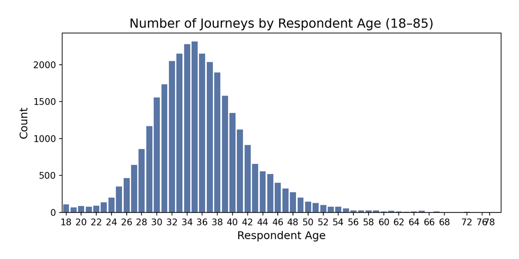

```python
# Labels and title
plt.title("Number of Journeys by Respondent Age (18–85)", fontsize=14)
plt.xlabel("Respondent Age", fontsize=12)
plt.ylabel("Count", fontsize=12)

# Adjust layout
plt.tight_layout(pad=2)
plt.subplots_adjust(left=0.12)
plt.show()
```

# younger/older sibling in hh

```python
#Whether ther's a younger/older sibling presents in HH
df['10to17_hh'] = df['AgeSimple'].apply(
    lambda x: 1 if 9 < x < 18 else 0
)

df['0to9_hh'] = df['AgeSimple'].apply(
    lambda x: 1 if 0 <= x <= 9 else 0
)
```

#The number of younger/older sibling in HH

```python
# Step 1: Recalculate number of children per age group in household
df["Num_0_9"] = df["HousehNumPers"] - df["HousehNumPers1084"]
households_with_85plus = df[df["AgeSimple"] >= 85]["SessionId"].unique()
df.loc[df["SessionId"].isin(households_with_85plus), "Num_0_9"] = np.nan

df["Num_0_17"] = df["HousehNumPers"] - df["HousehNumAdults"]
df["Num_10_17"] = df["Num_0_17"] - df["Num_0_9"]
df.loc[df["Num_10_17"] < 0, "Num_10_17"] = np.nan
df = df.dropna(subset=["Num_10_17"])

# Step 2: Get one row per household
household_df = df.drop_duplicates("SessionId")[["SessionId", "Num_0_9", "Num_10_17"]].copy()

n09 = household_df["Num_0_9"].fillna(0)
n1017 = household_df["Num_10_17"].fillna(0)

# Step 3: Create binary indicators
household_df["ChildinHH_017"] = ((n09 > 0) & (n1017 > 0)).astype(int)
household_df["ChildinHH_09"] = ((n09 > 0) & (n1017 == 0)).astype(int)
household_df["ChildinHH_1017"] = ((n09 == 0) & (n1017 > 0)).astype(int)
household_df["ChildinHH_None"] = ((n09 == 0) & (n1017 == 0)).astype(int)

# Optional: merge back if needed
df = df.merge(
    household_df[["SessionId", "ChildinHH_017", "ChildinHH_09", "ChildinHH_1017", "ChildinHH_None"]],
    on="SessionId",
    how="left"
)

df = df[df["ChildinHH_None"] == 0]
df = df[df["ChildinHH_1017"] == 0]
df = df[df['10to17_hh'] == 0]
```

```python
counts = df.groupby('10to17_hh')['SessionId'].nunique()
percentages1 = counts / counts.sum() * 100

counts = df.groupby('0to9_hh')['SessionId'].nunique()
percentages2 = counts / counts.sum() * 100

counts = df.groupby('ChildinHH_017')['SessionId'].nunique()
percentages3 = counts / counts.sum() * 100

counts = df.groupby('ChildinHH_09')['SessionId'].nunique()
percentages4 = counts / counts.sum() * 100

counts = df.groupby('ChildinHH_1017')['SessionId'].nunique()
percentages5 = counts / counts.sum() * 100

percentages1
```

```
## 10to17_hh
## 0    100.0
## Name: SessionId, dtype: float64
```

```python
percentages2
```

```
## 0to9_hh
## 0    48.375813
## 1    51.624187
## Name: SessionId, dtype: float64
```

```python
percentages3
```

```
## ChildinHH_017
## 0    100.0
## Name: SessionId, dtype: float64
```

```python
percentages4
```

```
## ChildinHH_09
## 1    100.0
## Name: SessionId, dtype: float64
```

```python
percentages5
```

```
## ChildinHH_1017
## 0    100.0
## Name: SessionId, dtype: float64
```

```python
counts = df.groupby('Num_0_17')['SessionId'].nunique()
percentages = counts / counts.sum() * 100

summary = pd.DataFrame({
    'Number of Children (Age 0–17) in a Family': counts.index,
    'Count': counts.values,
    'Percentage': percentages.round(2)
})

counts = df.groupby('Num_0_9')['SessionId'].nunique()
percentages = counts / counts.sum() * 100

summary1 = pd.DataFrame({
    'Number of Children (Age 0–9) in a Family': counts.index,
    'Count': counts.values,
    'Percentage': percentages.round(2)
})

counts = df.groupby('Num_10_17')['SessionId'].nunique()
percentages = counts / counts.sum() * 100

summary2 = pd.DataFrame({
    'Number of Children (Age 10–17) in a Family': counts.index,
    'Count': counts.values,
    'Percentage': percentages.round(2)
})

print(summary)
```

```
##           Number of Children (Age 0–17) in a Family  Count  Percentage
## Num_0_17
## 1.0                                             1.0   8502       42.35
## 2.0                                             2.0   9729       48.46
## 3.0                                             3.0   1726        8.60
## 4.0                                             4.0    111        0.55
## 5.0                                             5.0      7        0.03
```

```python
print(summary1)
```

```
##          Number of Children (Age 0–9) in a Family  Count  Percentage
## Num_0_9
## 1.0                                           1.0   8502       42.35
## 2.0                                           2.0   9729       48.46
## 3.0                                           3.0   1726        8.60
## 4.0                                           4.0    111        0.55
## 5.0                                           5.0      7        0.03
```

```python
print(summary2)
```

```
##            Number of Children (Age 10–17) in a Family  Count  Percentage
## Num_10_17
## 0.0                                               0.0  20075       100.0
```

###N of people in the HH

```python
# Group by age and count unique journeys
number_HH_member = df.groupby("HousehNumPers")["SessionId"].nunique().reset_index()

# Rename columns
number_HH_member.columns = ["HousehNumPers", "Number of Persons in a HH"]

# Sort by age (optional)
number_HH_member = number_HH_member.sort_values("HousehNumPers").reset_index(drop=True)

import matplotlib.pyplot as plt
import seaborn as sns

# Set seaborn style
sns.set(style="whitegrid")

# Create bar plot
plt.figure(figsize=(8, 4))
sns.barplot(data=number_HH_member, x="HousehNumPers", y="Number of Persons in a HH", color="#4C72B0")

# Add labels and title
plt.title("Number of Persons in a HH (total)", fontsize=14)
plt.xlabel("Persons in a Household")
plt.ylabel("Count")
plt.xticks(rotation=0)
```

```
## (array([0, 1, 2, 3, 4, 5, 6, 7, 8]), [Text(0, 0, '2.0'), Text(1, 0, '3.0'), Text(2, 0, '4.0'), Text(3, 0, '5.0'), Text(4, 0, '6.0'), Text(5, 0, '7.0'), Text(6, 0, '8.0'), Text(7, 0, '9.0'), Text(8, 0, '13.0')])
```

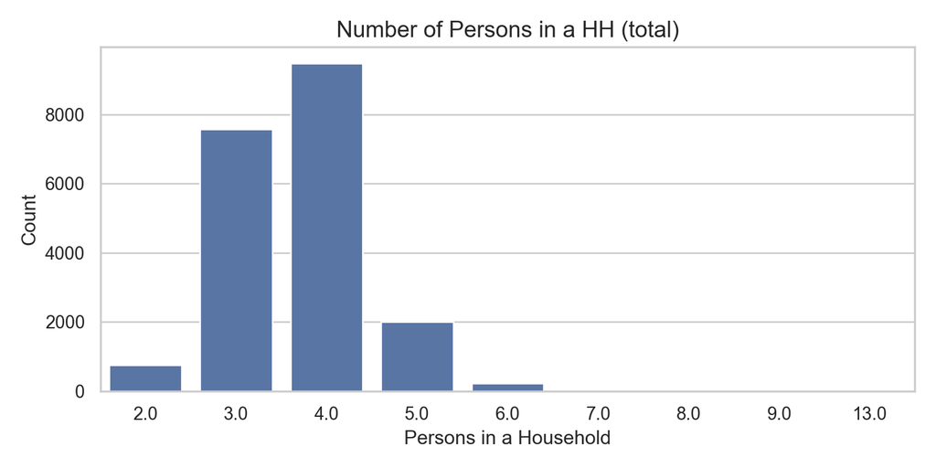

```python
plt.tight_layout()

# Show plot
plt.show()
```

```python
# Group by age and count unique journeys
number_HH_member = df.groupby("Num_0_9")["SessionId"].nunique().reset_index()

# Rename columns
number_HH_member.columns = ["Num_0_9", "Number of Persons U10 in a HH"]

# Sort by age (optional)
number_HH_member = number_HH_member.sort_values("Num_0_9").reset_index(drop=True)

import matplotlib.pyplot as plt
import seaborn as sns

# Set seaborn style
sns.set(style="whitegrid")

# Create bar plot
plt.figure(figsize=(8, 4))
sns.barplot(data=number_HH_member, x="Num_0_9", y="Number of Persons U10 in a HH", color="#4C72B0")

# Add labels and title
plt.title("Number of  Children under 10y in a HH (total)", fontsize=14)
plt.xlabel("Children in a Household")
plt.ylabel("Count")
plt.xticks(rotation=0)
```

```
## (array([0, 1, 2, 3, 4]), [Text(0, 0, '1.0'), Text(1, 0, '2.0'), Text(2, 0, '3.0'), Text(3, 0, '4.0'), Text(4, 0, '5.0')])
```

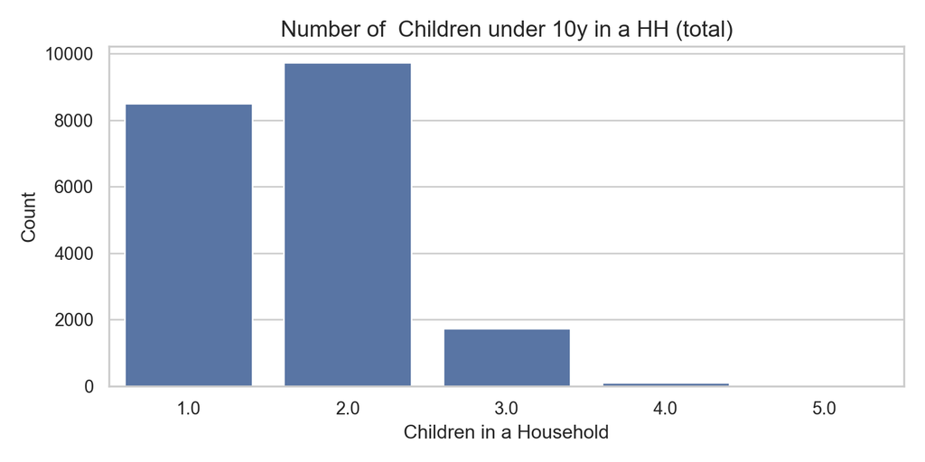

```python
plt.tight_layout()

# Show plot
plt.show()
```

# Travel time in minutes (‘Time of end of the journey’-‘Time of start of the journey’)

```
##    JStartTimeMsm  JEndTimeMsm  TravelTimeMinutes
## 0            470          815                345
## 1            470          815                345
## 2            470          815                345
## 3            470          815                345
## 4            470          815                345
```

# Purpose of journey (the purpose of the longest staying time of the journey)

```
##     PrimTargetPurp    PrimTargetPurp_Cat
## 0             11.0                  work
## 1             11.0                  work
## 2             11.0                  work
## 3             11.0                  work
## 4             11.0                  work
## 5             11.0                  work
## 6             31.0  errands and shopping
## 7             31.0  errands and shopping
## 8             31.0  errands and shopping
## 9             31.0  errands and shopping
## 10            31.0  errands and shopping
## 11            31.0  errands and shopping
## 12            31.0  errands and shopping
## 13            31.0  errands and shopping
```

[output cut: 16 more lines]

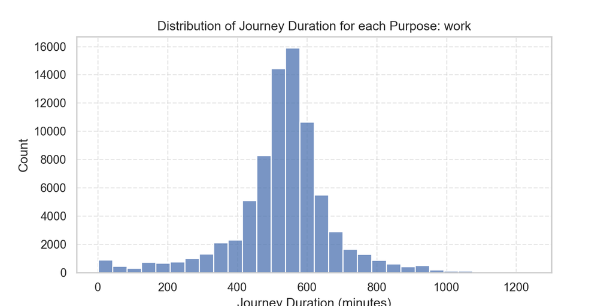

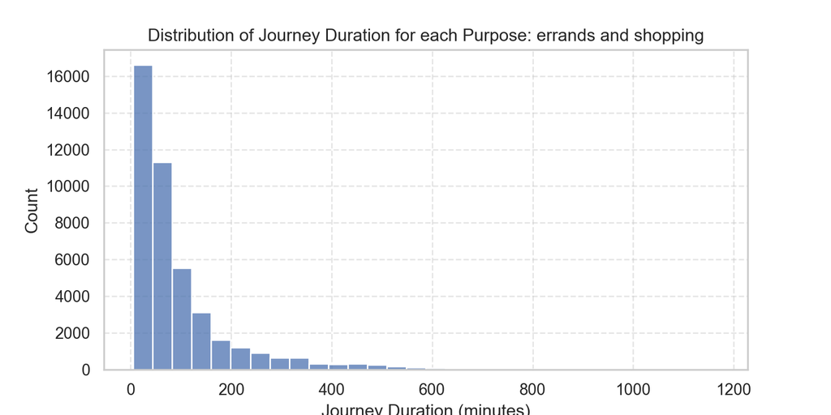

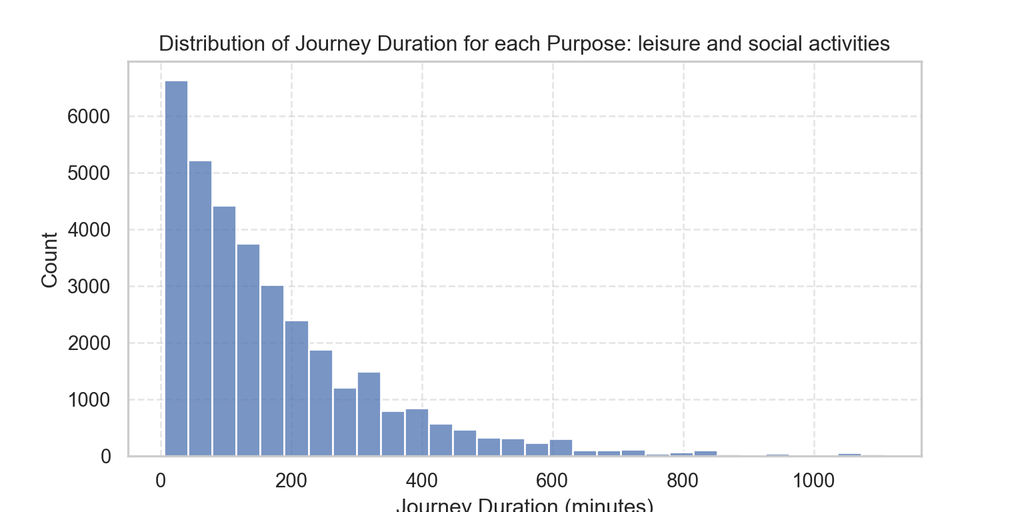

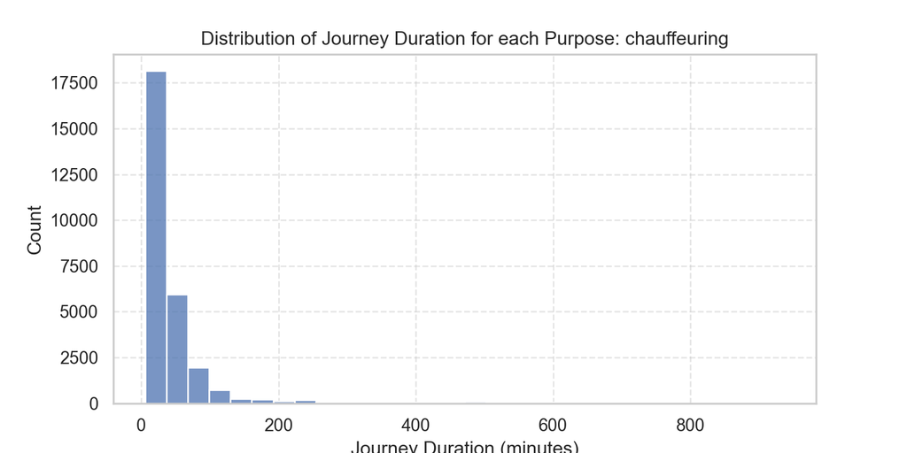

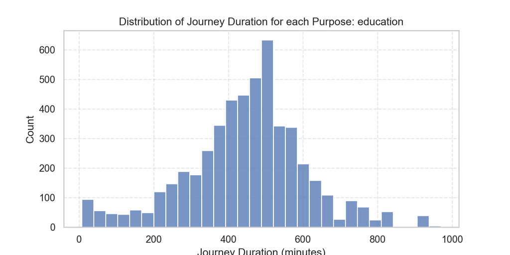

```python
import matplotlib.pyplot as plt
import seaborn as sns

categories = df["PrimTargetPurp_Cat"].unique()

for cat in categories:
    plt.figure(figsize=(8, 4))
    subset = df[df["PrimTargetPurp_Cat"] == cat]

    sns.histplot(subset["TravelTimeMinutes"].dropna(), bins=30, kde=False)
    plt.title(f"Distribution of Journey Duration for each Purpose: {cat}")
    plt.xlabel("Journey Duration (minutes)")
    plt.ylabel("Count")
    plt.grid(True, linestyle='--', alpha=0.5)
    plt.show()
```

# The number of children in the household and the age group of the oldest children

```
##    HousehNumPers  HousehNumAdults  ...  PartyNum1017  Chldu6
## 0            4.0              2.0  ...           0.0     1.0
## 1            4.0              2.0  ...           0.0     1.0
## 2            4.0              2.0  ...           0.0     1.0
## 3            4.0              2.0  ...           0.0     1.0
## 4            4.0              2.0  ...           0.0     1.0
## 5            4.0              2.0  ...           0.0     1.0
## 6            4.0              2.0  ...           0.0     1.0
## 7            4.0              2.0  ...           0.0     1.0
## 8            4.0              2.0  ...           0.0     1.0
## 9            4.0              2.0  ...           0.0     1.0
##
## [10 rows x 7 columns]
```

# Household type (single-adult households, dual-adult households, and multi-adult households)

```
##    PosInFamily               HhStruct
## 0         11.0       Couple household
## 1         20.0  Multi-adult household
## 2         20.0  Multi-adult household
## 3         11.0       Couple household
## 4         20.0  Multi-adult household
## 5         20.0  Multi-adult household
## 6         11.0       Couple household
## 7         20.0  Multi-adult household
## 8         20.0  Multi-adult household
## 9         11.0       Couple household
```

# Dummy for men/women in a couple, or younger/older

```
##    PosInFamily  RespSex  OlderInCouple  YoungerInCouple  IsMan  IsWoman
## 0         11.0        2              1                0      0        1
## 1         20.0        2              0                0      0        1
## 2         20.0        2              0                0      0        1
## 3         11.0        2              1                0      0        1
## 4         20.0        2              0                0      0        1
## 5         20.0        2              0                0      0        1
## 6         11.0        2              1                0      0        1
## 7         20.0        2              0                0      0        1
## 8         20.0        2              0                0      0        1
## 9         11.0        2              1                0      0        1
```

# Dummy for work status in a couple

```
##     RespPrimOcc  IsWorker  IsNonWorker
## 0         210.0         1            0
## 3         210.0         1            0
## 6         210.0         1            0
## 9         210.0         1            0
## 12        210.0         1            0
## 15        210.0         1            0
## 18        210.0         1            0
## 21        210.0         1            0
## 24        210.0         1            0
## 27        210.0         1            0
```

```
## IsWorker
## 0    0.152136
## 1    0.847864
## Name: SessionId, dtype: float64
```

# Single-adult/ multi-adult categorical variable

```
##     HousehNumAdults  SingleAdult  MultiAdult
## 0               2.0            0           1
## 3               2.0            0           1
## 6               2.0            0           1
## 9               2.0            0           1
## 12              2.0            0           1
## 15              2.0            0           1
## 18              2.0            0           1
## 21              2.0            0           1
## 24              2.0            0           1
## 27              2.0            0           1
```

# Check if the value of children traveler differs between trip level and journey level 0-9

```
## Number of journeys with inconsistent PartyNumu10 values: 7850
```

```
##      JourneyId  TurId  PartyNumu10
## 21        4514   4508            2
## 24        4514   4509            1
## 27        4514   4510            0
## 30        4514   4511            0
## 33        4514   4512            2
## 36        4514   4514            2
## 15        4713   4506            0
## 18        4713   4507            0
## 98        4713   4713            2
## 147       4870   4867            0
## 150       4870   4868            0
## 153       4870   4869            0
## 156       4870   4870            2
## 173       4889   4888            2
## 176       4889   4889            1
## 179       4891   4890            1
## 182       4891   4891            2
## 185       4894   4892            2
## 188       4894   4893            0
## 191       4894   4894            0
```

# Check if the value of children traveler differs between trip level and journey level 10-17

```
## Number of journeys with inconsistent PartyNum1017 values: 0
```

```
## Empty DataFrame
## Columns: [JourneyId, TurId, PartyNum1017]
## Index: []
```

# Check if the value of children traveler differs between trip level and journey level 0-17

```python
df["PartyNum017"] = df["PartyNumu10"].fillna(0) + df["PartyNum1017"].fillna(0)
```

```
## Number of journeys with inconsistent PartyNum017 values: 7850
```

```
##      JourneyId  TurId  PartyNum017
## 21        4514   4508          2.0
## 24        4514   4509          1.0
## 27        4514   4510          0.0
## 30        4514   4511          0.0
## 33        4514   4512          2.0
## 36        4514   4514          2.0
## 15        4713   4506          0.0
## 18        4713   4507          0.0
## 98        4713   4713          2.0
## 147       4870   4867          0.0
## 150       4870   4868          0.0
## 153       4870   4869          0.0
## 156       4870   4870          2.0
## 173       4889   4888          2.0
## 176       4889   4889          1.0
## 179       4891   4890          1.0
## 182       4891   4891          2.0
## 185       4894   4892          2.0
## 188       4894   4893          0.0
## 191       4894   4894          0.0
```

# Maximum number of accompanied children 0-17, 0-9, 10-17 per journey

```
##    JourneyId  PartyNum017  ...  PartyNum1017  PartyNum1017_max
## 0       4486          0.0  ...           0.0               0.0
## 1       4486          0.0  ...           0.0               0.0
## 2       4492          1.0  ...           0.0               0.0
## 3       4492          1.0  ...           0.0               0.0
## 4       4492          1.0  ...           0.0               0.0
## 5       4713          0.0  ...           0.0               0.0
## 6       4713          0.0  ...           0.0               0.0
## 7       4514          2.0  ...           0.0               0.0
## 8       4514          1.0  ...           0.0               0.0
## 9       4514          0.0  ...           0.0               0.0
##
## [10 rows x 7 columns]
```

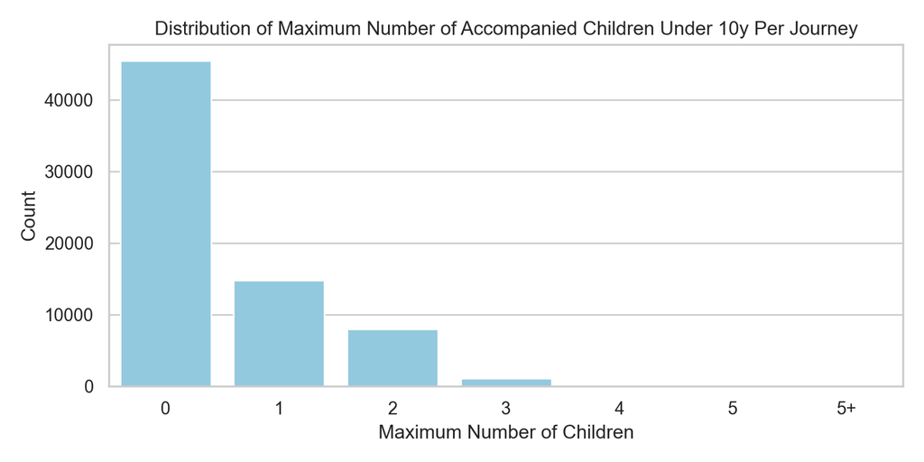

```python
bins = [-1, 0, 1, 2, 3, 4, 5, float('inf')]
labels = ['0', '1', '2', '3', '4', '5', '5+']
df['PartyNumu10_Category'] = pd.cut(df['PartyNumu10'], bins=bins, labels=labels, right=True, include_lowest=True)

chld_counts = df['PartyNumu10_Category'].value_counts().sort_index()

plt.figure(figsize=(8, 4))
sns.barplot(x=chld_counts.index.astype(str), y=chld_counts.values, color='skyblue')
plt.xlabel("Maximum Number of Children")
plt.ylabel("Count")
plt.title("Distribution of Maximum Number of Accompanied Children Under 10y Per Journey")
plt.tight_layout()
plt.show()
```

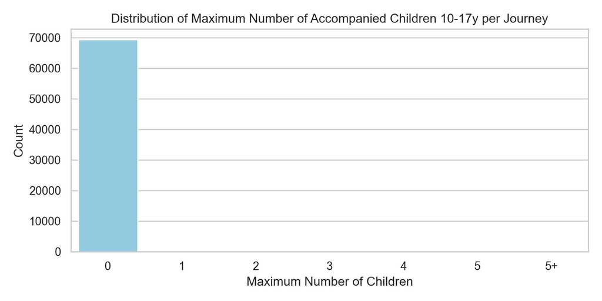

```python
bins = [-1, 0, 1, 2, 3, 4, 5, float('inf')]
labels = ['0', '1', '2', '3', '4', '5', '5+']
df['PartyNum1017_Category'] = pd.cut(df['PartyNum1017'], bins=bins, labels=labels, right=True, include_lowest=True)

chld_counts1 = df['PartyNum1017_Category'].value_counts().sort_index()

plt.figure(figsize=(8, 4))
sns.barplot(x=chld_counts1.index.astype(str), y=chld_counts1.values, color='skyblue')
plt.xlabel("Maximum Number of Children")
plt.ylabel("Count")
plt.title("Distribution of Maximum Number of Accompanied Children 10-17y per Journey")
plt.tight_layout()
plt.show()
```

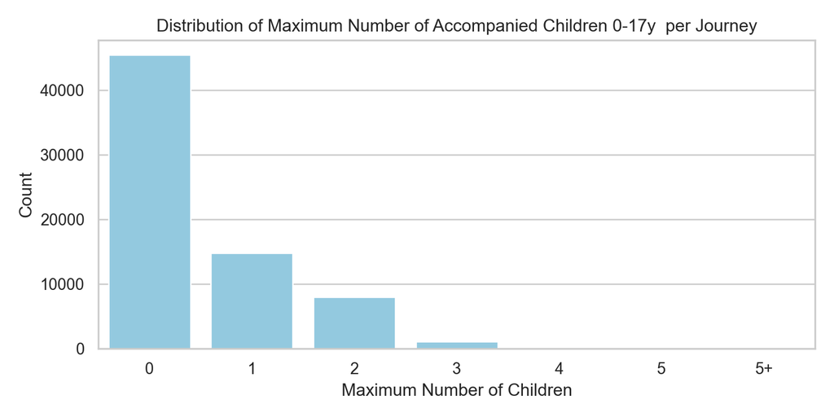

```python
bins = [-1, 0, 1, 2, 3, 4, 5, float('inf')]
labels = ['0', '1', '2', '3', '4', '5', '5+']
df['PartyNumu017_Category'] = pd.cut(df['PartyNum017'], bins=bins, labels=labels, right=True, include_lowest=True)

chld_counts2 = df['PartyNumu017_Category'].value_counts().sort_index()

plt.figure(figsize=(8, 4))
sns.barplot(x=chld_counts2.index.astype(str), y=chld_counts2.values, color='skyblue')
plt.xlabel("Maximum Number of Children")
plt.ylabel("Count")
plt.title("Distribution of Maximum Number of Accompanied Children 0-17y  per Journey")
plt.tight_layout()
plt.show()
```

```python
summary_table = pd.DataFrame({
    'Child Presence Category': chld_counts.index.astype(str),
    'Count': chld_counts.values,
    'Percentage': (chld_counts / chld_counts.sum() * 100).round(2)
})

print(summary_table)
```

```
##                      Child Presence Category  Count  Percentage
## PartyNumu10_Category
## 0                                          0  45477       65.50
## 1                                          1  14743       21.24
## 2                                          2   7988       11.51
## 3                                          3   1053        1.52
## 4                                          4    133        0.19
## 5                                          5     22        0.03
## 5+                                        5+     11        0.02
```

```python
summary_table = pd.DataFrame({
    'Child Presence Category': chld_counts1.index.astype(str),
    'Count': chld_counts1.values,
    'Percentage': (chld_counts1 / chld_counts1.sum() * 100).round(2)
})

print(summary_table)
```

```
##                       Child Presence Category  Count  Percentage
## PartyNum1017_Category
## 0                                           0  69427       100.0
## 1                                           1      0         0.0
## 2                                           2      0         0.0
## 3                                           3      0         0.0
## 4                                           4      0         0.0
## 5                                           5      0         0.0
## 5+                                         5+      0         0.0
```

```python
summary_table = pd.DataFrame({
    'Child Presence Category': chld_counts2.index.astype(str),
    'Count': chld_counts2.values,
    'Percentage': (chld_counts2 / chld_counts2.sum() * 100).round(2)
})

print(summary_table)
```

```
##                       Child Presence Category  Count  Percentage
## PartyNumu017_Category
## 0                                           0  45477       65.50
## 1                                           1  14743       21.24
## 2                                           2   7988       11.51
## 3                                           3   1053        1.52
## 4                                           4    133        0.19
## 5                                           5     22        0.03
## 5+                                         5+     11        0.02
```

```python
summary_counts = df['PartyNumu10_max'].value_counts().sort_index()

summary_percent = summary_counts / summary_counts.sum() * 100

summary_table = pd.DataFrame({
    'Count': summary_counts,
    'Percentage': summary_percent.round(2)
}).reset_index().rename(columns={'index': 'MaxChildrenUnder10'})

print(summary_table)
```

```
##     PartyNumu10_max  Count  Percentage
## 0                 0  31814       45.82
## 1                 1  19847       28.59
## 2                 2  15285       22.02
## 3                 3   2161        3.11
## 4                 4    256        0.37
## 5                 5     44        0.06
## 6                 6      4        0.01
## 7                 7      3        0.00
## 8                 8      4        0.01
## 9                 9      4        0.01
## 10               12      2        0.00
## 11               38      3        0.00
```

```python
summary_counts = df['PartyNum1017_max'].value_counts().sort_index()

summary_percent = summary_counts / summary_counts.sum() * 100

summary_table = pd.DataFrame({
    'Count': summary_counts,
    'Percentage': summary_percent.round(2)
}).reset_index().rename(columns={'index': 'MaxChildrenUnder10'})

print(summary_table)
```

```
##    PartyNum1017_max  Count  Percentage
## 0               0.0  69427       100.0
```

# Number of accompanied children on a journey under 10y

```
##     Number of accompanied children on a journey under 17y  Count  Percentage
## 0                                                 0.0      11534       48.13
## 1                                                 1.0       6912       28.84
## 2                                                 2.0       4754       19.84
## 3                                                 3.0        661        2.76
## 4                                                 4.0         82        0.34
## 5                                                 5.0         16        0.07
## 6                                                 6.0          1        0.00
## 7                                                 7.0          1        0.00
## 8                                                 8.0          1        0.00
## 9                                                 9.0          2        0.01
## 10                                               12.0          1        0.00
## 11                                               38.0          1        0.00
```

```
##     Number of accompanied children on a journey 0-9  Count  Percentage
## 0                                                 0  11534       48.13
## 1                                                 1   6912       28.84
## 2                                                 2   4754       19.84
## 3                                                 3    661        2.76
## 4                                                 4     82        0.34
## 5                                                 5     16        0.07
## 6                                                 6      1        0.00
## 7                                                 7      1        0.00
## 8                                                 8      1        0.00
## 9                                                 9      2        0.01
## 10                                               12      1        0.00
## 11                                               38      1        0.00
```

```
##    Number of accompanied children on a journey 10-17  Count  Percentage
## 0                                                0.0  23966       100.0
```

```
##        JourneyId  PrimTargetPurp  PartyNum017_max
## 8939     1060802            21.0              9.0
## 27010    1250288            21.0              9.0
## 35556    2045095            21.0             12.0
## 59423    2562589            11.0              8.0
## 62503    2599253            45.0              6.0
## 63453    2610766            11.0              7.0
## 68812    2722086            11.0             38.0
```

# New variables ActivityTime and TransportDistance

```
##    TravelTimeMinutes  SumMin  ActivityTime  TransportDistance
## 0                345      30           315              24.00
## 1                345      30           315              24.00
## 2                250     100           150              89.00
## 3                250     100           150              89.00
## 4                250     100           150              89.00
## 5                570      75           495              68.79
## 6                570      75           495              68.79
## 7                549      51           498               6.50
## 8                549      51           498               6.50
## 9                549      51           498               6.50
```

# Journey complexity (the number of tours in a journey: single trip or trip chaining)

```
##    JourneyId  TurId   JourneyComplx
## 0       4486   4482  Simple Journey
## 1       4486   4486  Simple Journey
## 2       4492   4487   Trip Chaining
## 3       4492   4490   Trip Chaining
## 4       4492   4492   Trip Chaining
## 5       4713   4506   Trip Chaining
## 6       4713   4507   Trip Chaining
## 7       4514   4508   Trip Chaining
## 8       4514   4509   Trip Chaining
## 9       4514   4510   Trip Chaining
```

```python
# Plot the histogram
# Define travel time categories as labels
bins = [0, 50, 100,150, 200, 250, 300, 350, 400, 450, 500, 550, 600, 650, 700, 750, 800, 850, 900, 950, float('inf')]
labels = ['0–50', '50–100', '100–150', '150–200', '200–250', '250–300', '300-350', '350-400', '400-450',
          '450-500', '500-550', '550-600', '600-650', '650-700', '700-750', '750-800', '800-850', '850-900', '900-950', '950p']

# Assign category
df_adults['TravelTimeCategory'] = pd.cut(df_adults['TravelTimeMinutes'], bins=bins, labels=labels, right=False)

# Count frequencies
category_counts = df_adults['TravelTimeCategory'].value_counts().sort_index()

# Plot
plt.figure(figsize=(8, 4))
sns.barplot(x=category_counts.index, y=category_counts.values, color='skyblue')
plt.xlabel("Journey Duration (minutes)")
plt.ylabel("Count")
plt.title("Distribution of Journey Duration Categories")
plt.xticks(rotation=45)
```

```
## (array([ 0,  1,  2,  3,  4,  5,  6,  7,  8,  9, 10, 11, 12, 13, 14, 15, 16,
##        17, 18, 19]), [Text(0, 0, '0–50'), Text(1, 0, '50–100'), Text(2, 0, '100–150'), Text(3, 0, '150–200'), Text(4, 0, '200–250'), Text(5, 0, '250–300'), Text(6, 0, '300-350'), Text(7, 0, '350-400'), Text(8, 0, '400-450'), Text(9, 0, '450-500'), Text(10, 0, '500-550'), Text(11, 0, '550-600'), T…
```

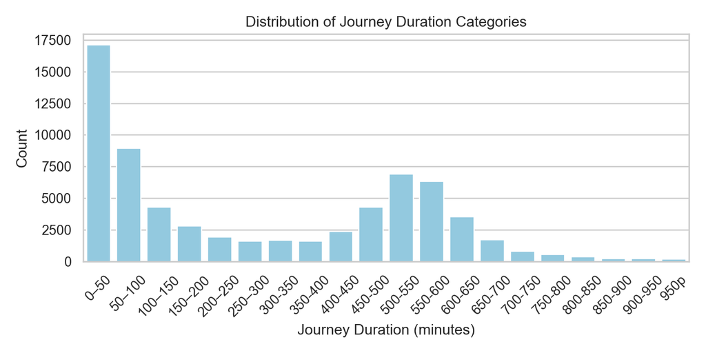

```python
plt.tight_layout()
plt.show()
```

```python
# Plot the histogram
# Define travel time categories as labels
bins = [0, 60, 120, 180, 240, 300, 360, 420, 480, 540, 600, 660, 720, float('inf')]
labels = ['0–60', '60–120', '120–180', '180–240', '240–300', '300–360',
          '360–420', '420–480', '480–540', '540–600', '600–660', '660–720', '720+']

# Apply cut
df_adults['TravelTimeCategory1'] = pd.cut(
    df_adults['TravelTimeMinutes'], bins=bins, labels=labels, right=False
)

# Count frequency per category
category_counts1 = df_adults['TravelTimeCategory1'].value_counts().sort_index()

# Plot
plt.figure(figsize=(8, 4))
sns.barplot(x=category_counts1.index, y=category_counts1.values, color='skyblue')
plt.xlabel("Journey Duration (minutes)")
plt.ylabel("Count")
plt.title("Distribution of Journey Duration Categories Under 12h")
plt.xticks(rotation=45)
```

```
## (array([ 0,  1,  2,  3,  4,  5,  6,  7,  8,  9, 10, 11, 12]), [Text(0, 0, '0–60'), Text(1, 0, '60–120'), Text(2, 0, '120–180'), Text(3, 0, '180–240'), Text(4, 0, '240–300'), Text(5, 0, '300–360'), Text(6, 0, '360–420'), Text(7, 0, '420–480'), Text(8, 0, '480–540'), Text(9, 0, '540–600'), Text(10,…
```

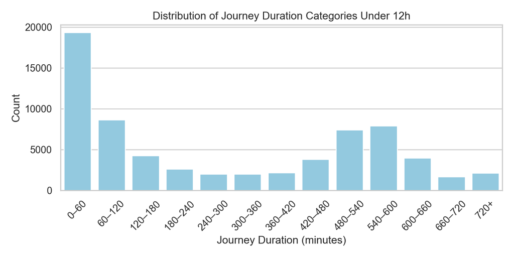

```python
plt.tight_layout()
plt.show()
```

```python
# Calculate percent of entries with TravelTimeMinutes > 720
percent_over_720 = (df_adults['TravelTimeMinutes'] > 720).mean() * 100
print(f"Percent of travel times over 720 minutes: {percent_over_720:.2f}%")
```

```
## Percent of travel times over 720 minutes: 2.99%
```

# Number of Journey Types with children under 10y

```
##    Journey Type  with children 0-10y  Count  Percentage
## 0                                  1   5233       22.10
## 1                                  2   7137       30.14
## 2                                  3  11306       47.75
```